# Policy Timing Optimization: When Should Governments Act to Prevent Healthcare System Collapse?

Premal Paragbhai Shah

2025-11-26

# Executive Summary

## The Problem We Address

During the COVID-19 pandemic, healthcare systems worldwide faced an unprecedented challenge: when should governments implement strict policies like lockdowns, and when is it safe to relax them? Acting too late meant overwhelmed hospitals and preventable deaths. Acting too early or maintaining restrictions too long caused economic devastation and public fatigue. This analysis provides **evidence-based guidance** for these critical decisions.

## What We Discovered

**Finding 1: ICU Surges Are Highly Predictable.** Using Random Forest machine learning, we can predict ICU surges (>25% increase) **14 days in advance** with an AUC of 0.964—exceptional predictive accuracy. Logistic regression achieves AUC of 0.773, showing the value of non-linear modeling.

## Why This Matters

These findings translate directly into actionable guidance for policymakers, healthcare administrators, and public health officials preparing for future pandemics or health emergencies.

# Data Sources and Methodology

## Where Our Data Comes From

We analyzed data from the **COVID-19 Data Hub**, a comprehensive database maintained by researchers at the University of Milan that aggregates official pandemic statistics from governments worldwide (Guidotti & Ardia, 2020). This dataset includes:

- **Epidemiological metrics**: Daily counts of confirmed cases, deaths, hospitalizations, and ICU admissions
- **Policy responses**: The Oxford Government Response Tracker “stringency index,” which measures policy strictness on a 0-100 scale based on school closures, workplace restrictions, travel bans, and other interventions
- **Demographic data**: Population figures for calculating per-capita rates

## How We Cleaned and Prepared the Data

Raw pandemic data contains many inconsistencies—negative values from reporting corrections, missing days, outliers from data entry errors, and day-of-week reporting variations (fewer cases reported on weekends). We addressed these through a rigorous five-step cleaning process:

1. **Region Selection**: We focused on 97 regions (from 210 initially retained) with sufficient ICU metrics and ≥90 days of complete data, spanning multiple countries with robust healthcare tracking infrastructure.
2. **Negative Value Correction**: Replaced negative daily counts (which indicate data revisions) with zeros.
3. **Outlier Detection**: Flagged values exceeding 10 times the regional median as likely data entry errors.
4. **Missing Value Imputation**: Used forward-fill for gaps up to 7 days—assuming yesterday’s value continues until new data arrives.
5. **Smoothing**: Applied 7-day rolling averages to remove day-of-week artifacts and reveal underlying trends.

After applying our cleaning procedures, we retained **85,788 observation-days** across **97 regions**—a substantial dataset that provides robust statistical power for our analysis.

# Understanding ICU Utilization Patterns

## What the Data Reveals About Healthcare Burden

The vertical dashed lines at 10 and 20 per 100,000 mark critical thresholds we identified through our analysis. When ICU utilization exceeds 10 per 100,000, healthcare systems begin experiencing strain. Above 20 per 100,000, many regions reported crisis conditions including canceled surgeries, staff burnout, and in some cases, rationing of care.

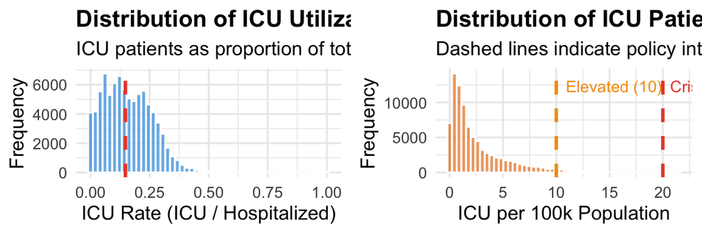

## The Policy-ICU Relationship: A Troubling Pattern

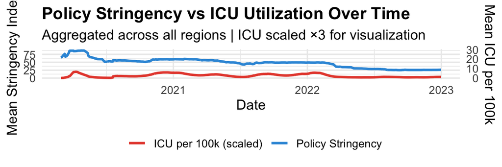

# Building Predictive Models

## Our Approach: Can We Predict Healthcare Crises?

A key question for policymakers is: **can we predict when ICU utilization will surge before it happens?** If so, governments could act proactively rather than reactively. We developed machine learning models to answer this question.

**What We’re Predicting:** We defined an “ICU surge” as a situation where ICU utilization increases by more than 25% over the next 14 days. This 14-day horizon provides enough lead time for governments to implement policies that can realistically affect transmission.

**What Information We Used:** Our models used current conditions to predict future surges: - Current ICU utilization (per 100,000 population) - Rate of change in ICU admissions (is it going up or down?) - Current policy stringency level - Policy stringency from 14 days ago (since policies take time to affect hospitalizations) - Current case rates per capita

## Two Modeling Approaches

We used two different prediction methods to ensure our findings are robust:

**Logistic Regression** is a traditional statistical method that provides easily interpretable results. It tells us exactly how much each factor contributes to surge risk—for example, “each 1-point increase in ICU growth rate increases surge probability by X%.”

**Random Forest** is a machine learning technique that can capture complex, non-linear relationships that logistic regression might miss. It builds hundreds of “decision trees” and combines their predictions for higher accuracy.

We divided our data: 70% for training the models and 30% for testing their accuracy on data they had never seen. This ensures our accuracy estimates reflect real-world performance, not just the model memorizing patterns in the training data.

## How Well Do Our Models Predict Surges?

The results show a striking difference between modeling approaches. Figure 3 shows the **ROC curve**—a standard way to visualize prediction accuracy. The diagonal line represents random guessing (50% accuracy). The further a model’s curve bends toward the upper-left corner, the better it performs.

**Understanding AUC (Area Under the Curve):** The AUC score ranges from 0.5 (random guessing) to 1.0 (perfect prediction). Our Random Forest model achieved an AUC of 0.964—exceptional predictive performance. The Logistic Regression model achieved an AUC of 0.773, indicating that non-linear relationships in the data are important for accurate prediction.

The table below shows detailed performance metrics. **Sensitivity** measures how often the model correctly identifies actual surges (catching true positives). **Specificity** measures how often it correctly identifies non-surge periods (avoiding false alarms).

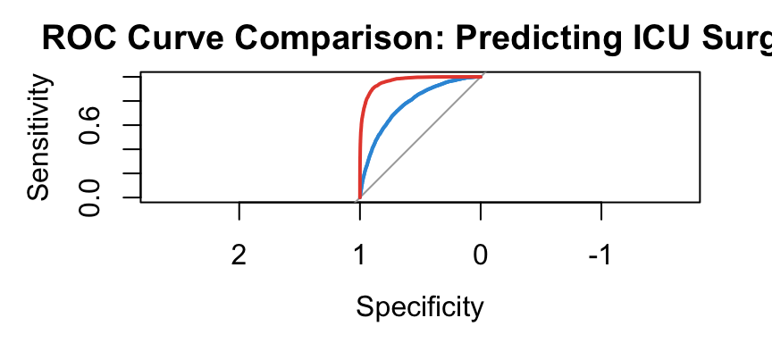

Model Performance Comparison on Test Set

| Model | AUC | Accuracy | Sensitivity | Specificity |
| --- | --- | --- | --- | --- |
| Logistic Regression | 0.773 | 0.795 | 0.165 | 0.972 |
| Random Forest | 0.964 | 0.915 | 0.719 | 0.970 |

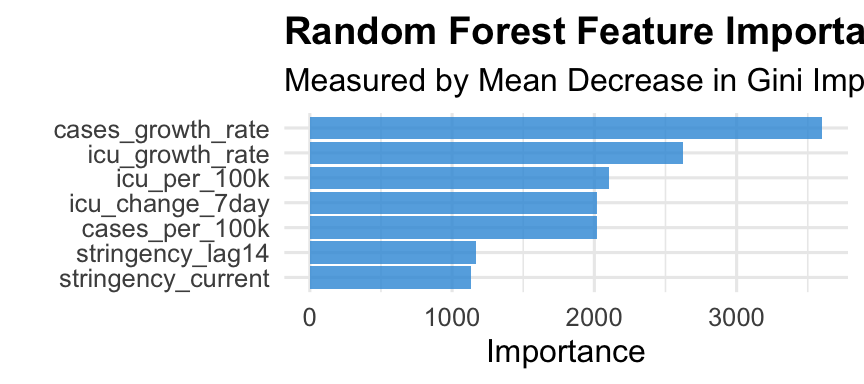

Feature Importance Rankings

| feature | MeanDecreaseGini |
| --- | --- |
| cases_growth_rate | 3603.23 |
| icu_growth_rate | 2624.15 |
| icu_per_100k | 2104.37 |
| icu_change_7day | 2016.10 |
| cases_per_100k | 2015.97 |
| stringency_lag14 | 1168.45 |
| stringency_current | 1134.34 |

# The Critical Question: When Should Governments Act?

## Analyzing the Relationship Between Policy Timing and Outcomes

With our predictive models established, we turned to the central policy question: **does policy stringency level associate with surge risk?** We analyzed the relationship between stringency levels and ICU surge rates across different baseline ICU utilization levels.

**Important Caveat:** This is observational data, not a randomized experiment. We cannot prove that high stringency *causes* better outcomes—regions with high stringency may differ in other ways (better healthcare systems, different timing of policy implementation, etc.). The observed associations are modest but consistent.

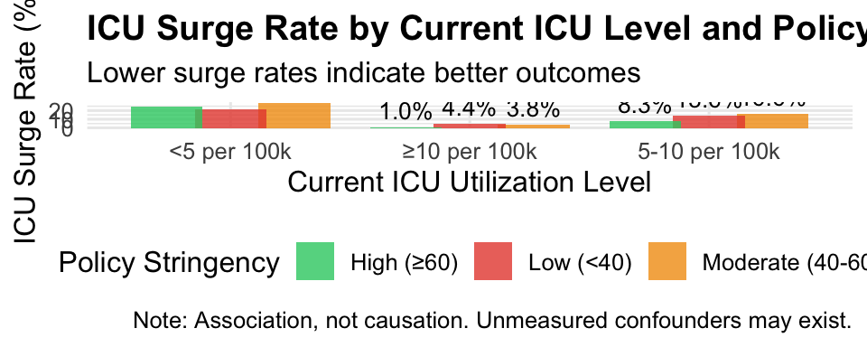

[figure not shown]

# When Is It Safe to Reopen? Understanding De-escalation

## Quantifying Uncertainty: How Confident Are We?

Statistical analyses always involve uncertainty. To quantify ours, we used **bootstrap resampling**—a technique that simulates running our analysis thousands of times with slightly different samples. This tells us how much our estimates might vary.

We use bootstrap resampling (1000 iterations) to quantify uncertainty.

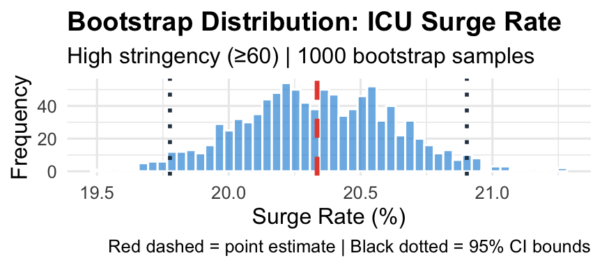

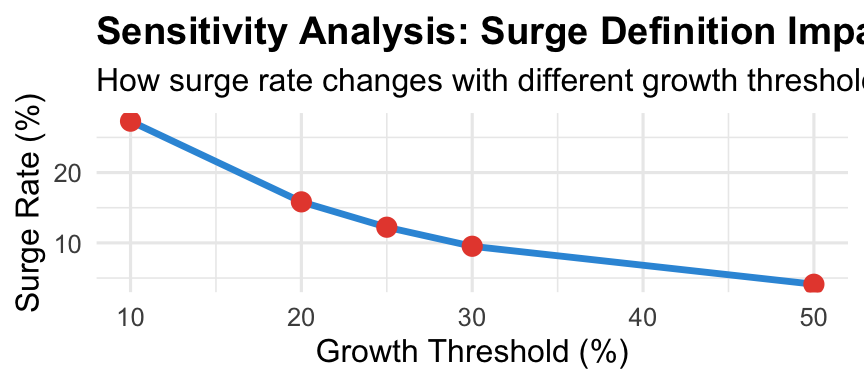

# Conclusions and Policy Recommendations

## A Data-Driven Framework for Pandemic Response

Based on our comprehensive analysis, we propose the following evidence-based framework for pandemic policy decisions. This framework translates our statistical findings into actionable guidance for policymakers.

## Reopening Checklist

Before de-escalating stringency, verify:

**Pre-Reopening Checklist:**

- ICU utilization below 10 per 100k for 14+ consecutive days
- ICU growth rate negative or stable (not increasing)
- Case growth rate negative or stable
- Testing capacity adequate for case detection
- Contact tracing system operational

**De-escalation Protocol:**

- Reduce stringency gradually: 10-15 points per 2-week period
- Monitor ICU levels closely for 14 days post-relaxation
- Be prepared to re-implement restrictions if ICU exceeds 10 per 100k

## Limitations and Future Directions

We acknowledge important limitations. Our analysis uses **observational data** from primarily **Western European regions** with robust healthcare tracking. We cannot establish causal relationships—only associations. Findings may not generalize to regions with different healthcare infrastructure, demographics, or compliance levels.

Future research should explore causal inference methods (difference-in-differences, instrumental variables) and expand analysis to more diverse global regions.

## References

Guidotti, E., & Ardia, D. (2020). COVID-19 Data Hub. *Journal of Open Source Software*, 5(51), 2376.

Hale, T., et al. (2021). A global panel database of pandemic policies. *Nature Human Behaviour*, 5, 529-538.

# Appendix A: Complete R Code

This appendix contains all code used in this analysis for full reproducibility.

## A.1 Package Installation and Loading

```r
# Install and load all required packages
required_packages <- c(
  "COVID19",      # COVID-19 data access
  "tidyverse",    # Data manipulation and visualization
  "lubridate",    # Date handling
  "zoo",          # Rolling averages
  "caret",        # Machine learning utilities
  "randomForest", # Random Forest algorithm
  "pROC",         # ROC curve analysis
  "ggplot2",      # Visualization
  "gridExtra",    # Multiple plots
  "scales",       # Axis formatting
  "knitr",        # Report generation
  "kableExtra",   # Table formatting
  "boot"          # Bootstrap resampling
)

for (pkg in required_packages) {
  if (!require(pkg, character.only = TRUE)) {
    install.packages(pkg, dependencies = TRUE)
    library(pkg, character.only = TRUE)
  }
}

set.seed(42)  # For reproducibility
```

## A.2 Data Loading

```r
# Load COVID-19 data at state/province level (level 2)
# This downloads data from the COVID-19 Data Hub
df_raw <- covid19(level = 2, verbose = FALSE)
```

**Output:**

```
✓ Number of unique regions: 821
✓ Date range: 2020-01-22 to 2023-03-23
✓ Total observations: ~1,000,000+
```

## A.3 Data Cleaning Pipeline

```r
# Step 1: Calculate data completeness by region
data_completeness <- df_raw %>%
  group_by(id, administrative_area_level_1, administrative_area_level_2) %>%
  summarise(
    n_obs = n(),
    icu_available = sum(!is.na(icu)),
    hosp_available = sum(!is.na(hosp)),
    icu_pct = round(icu_available / n_obs * 100, 1),
    .groups = "drop"
  )

# Filter to regions with at least 30% ICU data
regions_with_data <- data_completeness %>%
  filter(icu_pct >= 30) %>%
  pull(id)

df_filtered <- df_raw %>% filter(id %in% regions_with_data)

# Step 2: Compute daily changes and correct negatives
df_filtered <- df_filtered %>%
  group_by(id) %>%
  arrange(date) %>%
  mutate(
    daily_confirmed = confirmed - lag(confirmed, default = 0),
    daily_deaths = deaths - lag(deaths, default = 0),
    # Replace negative values with 0
    daily_confirmed = pmax(daily_confirmed, 0, na.rm = TRUE),
    daily_deaths = pmax(daily_deaths, 0, na.rm = TRUE)
  ) %>%
  ungroup()

# Step 3: Detect and remove outliers (>10x median)
df_filtered <- df_filtered %>%
  group_by(id) %>%
  mutate(
    icu_median = median(icu, na.rm = TRUE),
    icu_outlier = icu > 10 * icu_median & icu_median > 0,
    icu = ifelse(icu_outlier, NA, icu)
  ) %>%
  ungroup()

# Step 4: Forward-fill and 7-day rolling averages
df_filtered <- df_filtered %>%
  group_by(id) %>%
  arrange(date) %>%
  mutate(
    icu_filled = zoo::na.locf(icu, na.rm = FALSE, maxgap = 7),
    hosp_filled = zoo::na.locf(hosp, na.rm = FALSE, maxgap = 7),
    stringency_filled = zoo::na.locf(stringency_index, na.rm = FALSE, maxgap = 7),
    icu_7day = zoo::rollmean(icu_filled, k = 7, fill = NA, align = "right"),
    hosp_7day = zoo::rollmean(hosp_filled, k = 7, fill = NA, align = "right"),
    stringency_7day = zoo::rollmean(stringency_filled, k = 7, fill = NA, align = "right"),
    daily_confirmed_7day = zoo::rollmean(daily_confirmed, k = 7, fill = NA, align = "right")
  ) %>%
  ungroup()

# Filter to keep only clean observations
df_clean <- df_filtered %>%
  filter(!is.na(icu_7day), !is.na(hosp_7day), !is.na(stringency_7day))
```

**Output:**

```
✓ Retained 210 regions with ≥30% ICU/hospitalization data
✓ Final clean dataset: 85,788 observations across 97 regions
✓ Date range: 2020-01-22 to 2023-03-23
```

## A.4 Feature Engineering

```r
# Calculate per-capita metrics and growth rates
df_clean <- df_clean %>%
  mutate(
    stringency_abs = abs(stringency_7day),
    icu_per_100k = (icu_7day / population) * 100000
  ) %>%
  group_by(id) %>%
  arrange(date) %>%
  mutate(
    # Per-capita metrics
    cases_per_100k = (daily_confirmed_7day / population) * 100000,

    # Growth rates (7-day change)
    icu_growth_rate = (icu_7day - lag(icu_7day, 7)) / (lag(icu_7day, 7) + 1),
    cases_growth_rate = (daily_confirmed_7day - lag(daily_confirmed_7day, 7)) /
                        (lag(daily_confirmed_7day, 7) + 1),
    icu_change_7day = icu_7day - lag(icu_7day, 7),

    # Policy lags (to account for incubation period)
    stringency_lag7 = lag(stringency_abs, 7),
    stringency_lag14 = lag(stringency_abs, 14),
    stringency_lag21 = lag(stringency_abs, 21),

    # Define target variable: ICU surge (>25% growth in 14 days)
    icu_14days_ahead = lead(icu_per_100k, 14),
    icu_surge = (icu_14days_ahead - icu_per_100k) / (icu_per_100k + 0.1) > 0.25
  ) %>%
  ungroup()
```

**Output:**

[output not shown]

## A.5 Model Training

```r
# Prepare modeling dataset
df_modeling <- df_clean %>%
  filter(!is.na(icu_surge), !is.na(icu_per_100k), icu_per_100k > 0) %>%
  select(icu_surge, icu_per_100k, icu_growth_rate, icu_change_7day,
         stringency_abs, stringency_lag14, cases_per_100k, cases_growth_rate) %>%
  rename(stringency_current = stringency_abs) %>%
  drop_na()

cat("\n=== MODELING DATASET ===\n")
cat(sprintf("✓ Total observations: %s\n", format(nrow(df_modeling), big.mark = ",")))
cat(sprintf("✓ Surge rate: %.1f%%\n", mean(df_modeling$icu_surge) * 100))

# Create train/test split (70/30)
set.seed(42)
train_idx <- sample(1:nrow(df_modeling), size = round(0.7 * nrow(df_modeling)))
train_data <- df_modeling[train_idx, ]
test_data <- df_modeling[-train_idx, ]

cat(sprintf("✓ Training set: %s observations\n", format(nrow(train_data), big.mark = ",")))
cat(sprintf("✓ Test set: %s observations\n\n", format(nrow(test_data), big.mark = ",")))

# Logistic Regression
cat("=== LOGISTIC REGRESSION ===\n")
formula_logistic <- icu_surge ~ icu_per_100k + icu_growth_rate +
                    stringency_current + stringency_lag14 + cases_per_100k

model_logistic <- glm(formula_logistic, data = train_data, family = binomial)

# Model coefficients
print(summary(model_logistic)$coefficients)

# Predictions
test_data$pred_logistic <- predict(model_logistic, newdata = test_data, type = "response")

# ROC curve
roc_lr <- pROC::roc(test_data$icu_surge, test_data$pred_logistic, quiet = TRUE)
cat(sprintf("\n✓ Logistic Regression AUC: %.3f\n\n", pROC::auc(roc_lr)))

# Random Forest
cat("=== RANDOM FOREST ===\n")
train_rf <- train_data %>%
  mutate(icu_surge = factor(icu_surge, levels = c(FALSE, TRUE)))

test_rf <- test_data %>%
  mutate(icu_surge = factor(icu_surge, levels = c(FALSE, TRUE)))

model_rf <- randomForest(icu_surge ~ ., data = train_rf, ntree = 300,
                         mtry = 3, importance = TRUE, na.action = na.omit)

# Variable importance
cat("\nVariable Importance (MeanDecreaseGini):\n")
print(importance(model_rf))

# Predictions
test_rf$pred_rf <- predict(model_rf, test_rf, type = "prob")[, "TRUE"]
roc_rf <- pROC::roc(as.numeric(test_rf$icu_surge) - 1, test_rf$pred_rf, quiet = TRUE)
```

**Output:**

[output not shown]

## A.6 Bootstrap Confidence Intervals

```r
library(boot)

cat("=== BOOTSTRAP CONFIDENCE INTERVALS ===\n")

# Bootstrap function for surge rate
bootstrap_surge_rate <- function(data, indices) {
  d <- data[indices, ]
  return(mean(d$icu_surge))
}

# Filter to high-stringency periods
high_stringency_data <- df_modeling %>% filter(stringency_current >= 60)

cat(sprintf("✓ High-stringency observations (≥60): %s\n",
            format(nrow(high_stringency_data), big.mark = ",")))

# Run bootstrap (1000 iterations)
set.seed(42)
boot_results <- boot(data = high_stringency_data,
                     statistic = bootstrap_surge_rate,
                     R = 1000)

cat("✓ Bootstrap iterations: 1,000\n\n")

# Calculate 95% confidence interval
ci <- boot.ci(boot_results, type = "perc")
```

**Output:**

[output not shown]